# **DNA Methylation Pipeline Analysis in R**

Francesca Catalogne

22/07/2021

### Step 1

*Load raw data with minfi and create an object called RGset storing the RGChannelSet object.*

**This block will load minfi, a R library that provides the tools needed to analyze the Ilumina Methylation arrays. In this case we will be utilizing Illumina 450K array. Analysis and setting of the working directory is then done. Loading of raw data with minfi and creation of an object called RGset storing the RGChannelSet data that are the two color channels each sample is measured on within the single array.**

```r
rm(list=ls())
suppressMessages(library(minfi))
setwd("/Users/fcatalogne/Desktop/DRD/Report/")
baseDir <- ("./Input_data")
targets <- read.metharray.sheet(baseDir)
```

```
## [1] "./Input_data/Samplesheet_report_2021.csv"
```

```r
RGset <- read.metharray.exp(targets = targets)
RGset
```

```
## class: RGChannelSet
## dim: 622399 8
## metadata(0):
## assays(2): Green Red
## rownames(622399): 10600313 10600322 ... 74810490 74810492
## rowData names(0):
## colnames(8): 5775278051_R01C02 5775278078_R01C01 ... 5930514035_R06C02
##   5930514054_R06C01
## colData names(8): Sample_Name Group ... Basename filenames
## Annotation
##   array: IlluminaHumanMethylation450k
##   annotation: ilmn12.hg19
```

### Step 2

**Creation of the dataframes Red and Green to store the red and green fluorescences respectively within the array of 450,000 CpG positions.**

```r
Red <- data.frame(getRed(RGset))
Green <- data.frame(getGreen(RGset))
```

### Step 3

**Retrieving of red and green fluorescence for the address *18744490*:**

```r
probe_red <- Red[rownames(Red)=="18744490",]
probe_green <- Green[rownames(Green)=="18744490",]
probe_red
```

```
##          X5775278051_R01C02 X5775278078_R01C01 X5775278078_R02C01
## 18744490               3723                824               4109
##          X5775278078_R02C02 X5775278078_R04C02 X5930514034_R01C02
## 18744490                844                525               3761
##          X5930514035_R06C02 X5930514054_R06C01
## 18744490               4422                576
```

```r
probe_green
```

```
##          X5775278051_R01C02 X5775278078_R01C01 X5775278078_R02C01
## 18744490              10539               1649               9977
##          X5775278078_R02C02 X5775278078_R04C02 X5930514034_R01C02
## 18744490               1551                474               9184
##          X5930514035_R06C02 X5930514054_R06C01
## 18744490              13333                622
```

[output not shown]

#### *Optional*

**Checking in the manifest file if the address corresponds to a *Type I* or a *Type II* probe:**  
**Since each CpG is associated with two measurements, either “methylated” or “un-methylated”, there needs to be a distinction between the two that is recognizable, this is through Type I or Type II design.**  
**CpGs measured with Type I design use a single color, with two different probes in the same color channel providing the methylated and the un-methylated measurements.**  
**CpGs of Type II are measured using a single probe, and two different colors provide the methylated and the un-methylated measurements, therefore on this type of array, there is not a one-to-one correspondence between probes and CpG positions.**

```r
load("./Illumina450Manifest_clean.RData")
Illumina450Manifest_clean[Illumina450Manifest_clean$AddressA_ID=="18744490",]
```

```
##        IlmnID       Name AddressA_ID
## 34 cg01209756 cg01209756    18744490
##                                      AlleleA_ProbeSeq AddressB_ID
## 34 TTCCAAAAAACTCCAACCATAACAAACAAAACCATACACTAAACCATCTC
##    AlleleB_ProbeSeq Infinium_Design_Type Next_Base Color_Channel
## 34                                    II
##                                                                                                                Forward_Sequence
## 34 CCCGAAGTCTGTGCAGCGGATGGACACCTCTGGCGTCCTCACTCAGCAGCAGGGCGGCGC[CG]AGATGGTCCAGTGCATGGCCTTGTCTGCTATGGCTGGAGCCCCTTGGAAGCCGGCAGAAG
##    Genome_Build CHR  MAPINFO                                          SourceSeq
## 34           37   Y 19671414 TCCAAGGGGCTCCAGCCATAGCAGACAAGGCCATGCACTGGACCATCTCG
##    Chromosome_36 Coordinate_36 Strand Probe_SNPs Probe_SNPs_10 Random_Loci
## 34             Y      18180808      F                                   NA
##    Methyl27_Loci UCSC_RefGene_Name UCSC_RefGene_Accession UCSC_RefGene_Group
## 34            NA
##     UCSC_CpG_Islands_Name Relation_to_UCSC_CpG_Island Phantom DMR Enhancer
## 34 chrY:19671324-19671587                      Island                   NA
##             HMM_Island Regulatory_Feature_Name Regulatory_Feature_Group DHS
## 34 Y:18180750-18181287                                                   NA
```

*Within the column titled “type”, this specific address corresponds to a Type II probe, therefore no color channel is specified.*

### Step 4

**Creation of the object MSet.raw from the preprocessRaw function that is transforming the Red/Green channel for an Illumina methylation array into an actual methylation signal, without normalization.**

[output not shown]

### Step 5

**Performing the following quality checks on the channel:**  
*QCplot*

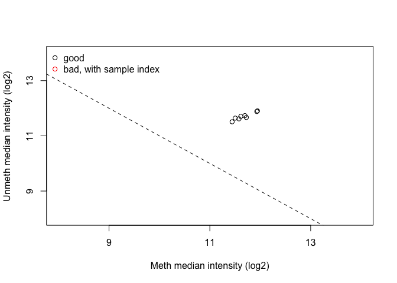

```r
qc <- getQC(MSet.raw)
plotQC(qc)
```

*This Quality Control plot contains the ratio of unmethylated to methylated medians, taking its binary log value, we see that the values are localized above the line, indicating high signals, therefore high quality results.*

**Strip plots are made for each control probe type specified.**

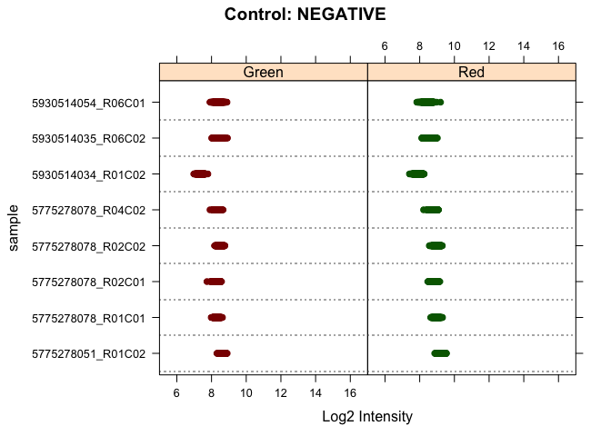

```r
controlStripPlot(RGset, controls="NEGATIVE")
```

*For what concerns the intensity, it is ideal to be below 1000, which evidently is the case, as the data falls below 10 since it is log base two. It should be noted that the green and red labels are swapped unintentionally in this schematic.*

**Next is the calculation of the detection pValues; for each sample, we calculate the probes that have a detection p-value higher than the threshold *0.05*.**

```r
detP <- detectionP(RGset)
failed <- detP>0.05
summary(failed)
```

```
##  5775278051_R01C02 5775278078_R01C01 5775278078_R02C01 5775278078_R02C02
##  Mode :logical     Mode :logical     Mode :logical     Mode :logical
##  FALSE:485275      FALSE:484932      FALSE:485248      FALSE:484916
##  TRUE :237         TRUE :580         TRUE :264         TRUE :596
##  5775278078_R04C02 5930514034_R01C02 5930514035_R06C02 5930514054_R06C01
##  Mode :logical     Mode :logical     Mode :logical     Mode :logical
##  FALSE:484919      FALSE:485421      FALSE:485397      FALSE:485055
##  TRUE :593         TRUE :91          TRUE :115         TRUE :457
```

| Sample | Failed |
| --- | --- |
| 5775278051_R01C02 | 237 |
| 5775278078_R01C01 | 580 |
| 5775278078_R02C01 | 264 |
| 5775278078_R02C02 | 596 |
| 5775278078_R04C02 | 593 |
| 5930514034_R01C02 | 91 |
| 5930514035_R06C02 | 115 |
| 5930514054_R06C01 | 457 |

### Step 6

**Calculation of the raw beta and M values with their plot of their densities of mean methylation values using the divided wild type (WT) and down syndrome (DS) sample** **It is recommended to subset the beta and M values matrices in order to retain DS or WT subjects and apply the function mean to the 2 subsets.**

**Subset the DS and WT and assign MSet to each:**

```r
MSet.raw
```

```
## class: MethylSet
## dim: 485512 8
## metadata(0):
## assays(2): Meth Unmeth
## rownames(485512): cg00050873 cg00212031 ... ch.22.47579720R
##   ch.22.48274842R
## rowData names(0):
## colnames(8): 5775278051_R01C02 5775278078_R01C01 ... 5930514035_R06C02
##   5930514054_R06C01
## colData names(8): Sample_Name Group ... Basename filenames
## Annotation
##   array: IlluminaHumanMethylation450k
##   annotation: ilmn12.hg19
## Preprocessing
##   Method: Raw (no normalization or bg correction)
##   minfi version: 1.36.0
##   Manifest version: 0.4.0
```

```r
csv <- read.csv("./Input_data/Samplesheet_report_2021.csv")
WT <- csv[csv$Group=='WT', 'Basename']
DS <- csv[csv$Group=='DS', 'Basename']
wtSet <- MSet.raw[,colnames(MSet.raw) %in% WT]
dsSet <- MSet.raw[,colnames(MSet.raw) %in% DS]
```

**Beta and M are calculated for each DS and WT subsets:**

```r
wtBeta <- getBeta(wtSet)
wtM <- getM(wtSet)

dsBeta <- getBeta(dsSet)
dsM <- getM(dsSet)
```

**Beta and M mean is calculated for each DS and WT, stripping NA values with na.rm=T:**

```r
mean_wtBeta <- apply(wtBeta,MARGIN=1,mean,na.rm=T)
mean_dsBeta <- apply(dsBeta,MARGIN=1,mean,na.rm=T)
mean_wtM <- apply(wtM,MARGIN=1,mean,na.rm=T)
mean_dsM <- apply(dsM,MARGIN=1,mean,na.rm=T)
```

**Calculation of the density distribution on Beta values:**

```r
d_mean_wtBeta <- density(mean_wtBeta,na.rm=T)
d_mean_dsBeta <- density(mean_dsBeta, na.rm=T)
```

**Apply the same steps on M values:**

```r
d_mean_dsM <- density(mean_dsM)
d_mean_wtM <- density(mean_wtM)
```

**A plot is created using an overlay of “mfrow”**

```r
par(mfrow=c(1,2))
par("mar")
```

```
## [1] 5.1 4.1 4.1 2.1
```

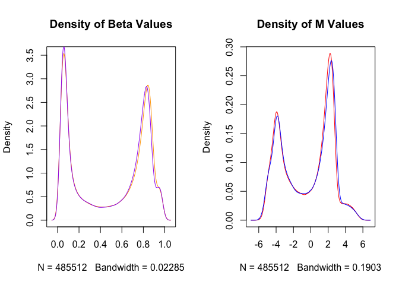

```r
plot(d_mean_wtBeta,main="Density of Beta Values",col="orange")
lines(d_mean_dsBeta,main="Density of Beta Values",col="purple")
plot(d_mean_dsM,main="Density of M Values",col="red")
lines(d_mean_wtM,main="Density of M Values",col="blue")
```

### Step 7

**Normalize the data using the function preprocessQuantile and compare raw data and normalized data.**

**This function implements stratified quantile normalization preprocessing. The normalization procedure is applied to the Meth and Unmeth intensities separately. The distribution of type I and type II signals is forced to be the same by first quantile normalizing the type II probes across samples and then interpolating a reference distribution to which we normalize the type I probes.**

**Subset the manifest into dfI and dfII in order to obtain raw beta probe values next by getting only Type I or Type II probes:**

```r
dfI <- Illumina450Manifest_clean[Illumina450Manifest_clean$Infinium_Design_Type=="I",]
dfI <- droplevels(dfI)
dfII <- Illumina450Manifest_clean[Illumina450Manifest_clean$Infinium_Design_Type=="II",]
dfII <- droplevels(dfII)
```

**Names of the probes stored in row names and beta values from the beta matrix that are also found in the manifest from each probe:**

```r
beta <- getBeta(MSet.raw)
beta_I <- beta[rownames(beta) %in% dfI$IlmnID,]
beta_II <- beta[rownames(beta) %in% dfII$IlmnID,]
```

**Mean of the unprocessed data:**

```r
mean_beta_I <- apply(beta_I,1,mean)
mean_beta_II <- apply(beta_II,1,mean)
```

**Density of the mean of the unprocessed data:**

```r
d_mean_beta_I <- density(mean_beta_I,na.rm=T)
d_mean_beta_II <- density(mean_beta_II,na.rm=T)
```

**For the Raw data, components included are the:matrix of beta values, the d_mean_beta_I and d_mean_beta_II objects**

**Standard deviations:**

```r
sd_beta_I <- apply(beta_I,1,sd,na.rm=T)
sd_beta_II <- apply(beta_II,1,sd,na.rm=T)
```

**Density of the standard deviation:**

```r
d_sd_beta_I <- density(sd_beta_I,)
d_sd_beta_II <- density(sd_beta_II)
```

**Normalization is applied using the RGSet input which is the raw intensities of the red and green channels, and normalization function ‘preprocessQuantile’ that will stratify the microarray by CpG region such as island, shore, sea:**

```r
preprocessQUANT_results <- preprocessQuantile(RGset)
```

**Repeat the process for the normalized data:**  
**Assign the normalized function to beta probes:**

```r
beta_preprocessQUANT <- getBeta(preprocessQUANT_results)
```

**Assign those found in the array and the corresponding row names in the beta probe values:**

```r
beta_preprocessQUANT_I <- beta_preprocessQUANT[rownames(beta_preprocessQUANT) %in% dfI$IlmnID,]
beta_preprocessQUANT_II <- beta_preprocessQUANT[rownames(beta_preprocessQUANT) %in% dfII$IlmnID,]
```

**Mean of the normalized values:**

```r
mean_beta_preprocessQUANT_I <- apply(beta_preprocessQUANT_I,1,mean)
mean_beta_preprocessQUANT_II <- apply(beta_preprocessQUANT_II,1,mean)
```

**Density of the mean of the normalized values:**

```r
d_mean_beta_preprocessQUANT_I <- density(mean_beta_preprocessQUANT_I,na.rm=T)
d_mean_beta_preprocessQUANT_II <- density(mean_beta_preprocessQUANT_II,na.rm=T)
```

**Standard deviation of the values:**

```r
sd_beta_preprocessQUANT_I <- apply(beta_preprocessQUANT_I,1,sd)
sd_beta_preprocessQUANT_II <- apply(beta_preprocessQUANT_II,1,sd)
```

**Density of the standard deviation:**

```r
d_sd_beta_preprocessQUANT_I <- density(sd_beta_preprocessQUANT_I,na.rm=T)
d_sd_beta_preprocessQUANT_II <- density(sd_beta_preprocessQUANT_II,na.rm=T)
```

**A plot with 6 panels in which, for both raw and normalized data, is shown along with the density plots of beta mean values according to the chemistry of the probes.**

**The density plot of beta standard deviation values according to the chemistry of the probes and the boxplot of beta values:**

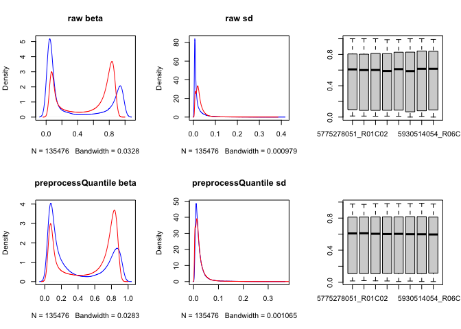

```r
par(mfrow=c(2,3))
plot(d_mean_beta_I,col="blue",main="raw beta")
lines(d_mean_beta_II,col="red")

plot(d_sd_beta_I,col="blue",main="raw sd")
lines(d_sd_beta_II,col="red")

boxplot(beta)
plot(d_mean_beta_preprocessQUANT_I,col="blue",main="preprocessQuantile beta")
lines(d_mean_beta_preprocessQUANT_II,col="red")
plot(d_sd_beta_preprocessQUANT_I,col="blue",main="preprocessQuantile sd")
lines(d_sd_beta_preprocessQUANT_II,col="red")
boxplot(beta_preprocessQUANT)
```

*The main objective of this comparison is between the raw data and the normalized data. From what is graphed, data coming from the beta values and their density mean show the the raw data has a greater variation at higher densities, with a lower type II probe density range towards lower methylation levels and at higher methylation levels. However where density is lowest and where the methylation levels are centered, it seems the point of intersection from the raw data occurs at lower methylation levels, where as after normalization it is more centered. The values of type I for high density at high methylation levels in normalized data seemed to stretch wider showing greater levels of high density at higher methylation levels, whereas for the type II probe, this peak at high methlyation levels seems to narrow, thus overall creating a closer overlay between the two probes at higher methylation levels within the normalized data. At low methylation levels, type II increased in density while the peak of type I falls at 4 for normalized data, where it was 5 for raw data. In regards to the box plots, it is evident that the data falls closer along the same line with a decreased number of outliers or standard deviation thus indicating higher quality and more reliable data.*

### Step 8

**Performance of a PCA on the beta matrix generated in step 7.**

```r
pca_results <- prcomp(t(beta_preprocessQUANT),scale=T)
print(summary(pca_results))
```

```
## Importance of components:
##                            PC1      PC2      PC3      PC4      PC5      PC6
## Standard deviation     327.575 278.6189 261.9020 253.8345 244.5390 234.7714
## Proportion of Variance   0.221   0.1599   0.1413   0.1327   0.1232   0.1135
## Cumulative Proportion    0.221   0.3809   0.5222   0.6549   0.7781   0.8916
##                             PC7      PC8
## Standard deviation     229.4264 4.12e-12
## Proportion of Variance   0.1084 0.00e+00
## Cumulative Proportion    1.0000 1.00e+00
```

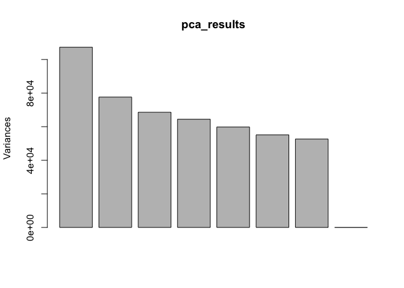

```r
plot(pca_results)
```

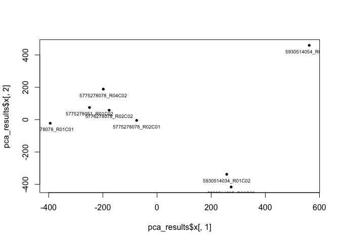

```r
palette(c("blue","red"))
plot(pca_results$x[,1], pca_results$x[,2],cex=0.9,pch=20)
text(pca_results$x[,1], pca_results$x[,2],labels=rownames(pca_results$x),pos=1, cex=0.6)
```

```r
pheno <- read.csv("./Samplesheet_report_2021.csv",header=T, stringsAsFactors=T)
str(pheno)
```

```
## 'data.frame':    8 obs. of  7 variables:
##  $ Sample_Name: int  1028 1038 3038 3046 1052 1016 3029 3037
##  $ Group      : Factor w/ 2 levels "DS","WT": 1 1 2 2 1 1 2 2
##  $ Age        : int  38 37 46 36 35 43 35 38
##  $ Sex        : int  0 1 0 1 1 0 0 1
##  $ Slide      : num  5.78e+09 5.78e+09 5.78e+09 5.78e+09 5.78e+09 ...
##  $ Array      : Factor w/ 7 levels "R01C01","R01C02",..: 2 1 3 4 5 2 7 6
##  $ Basename   : Factor w/ 8 levels "5775278051_R01C02",..: 1 2 3 4 5 6 7 8
```

```r
pheno$Group
```

```
## [1] DS DS WT WT DS DS WT WT
## Levels: DS WT
```

```r
levels(pheno$Group)
```

```
## [1] "DS" "WT"
```

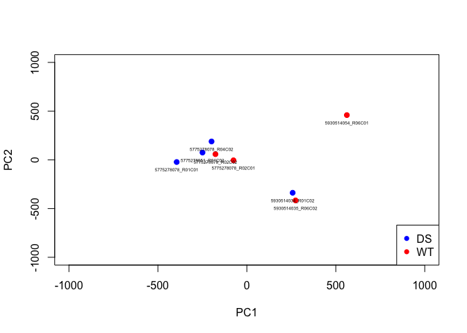

```r
palette(c("blue","red"))
plot(pca_results$x[,1], pca_results$x[,2],cex=1.5,pch=20,col=pheno$Group,xlab="PC1",ylab="PC2",xlim=c(-1000,1000),ylim=c(-1000,1000))
text(pca_results$x[,1], pca_results$x[,2],labels=rownames(pca_results$x),cex=0.4,pos=1)
legend("bottomright",legend=levels(pheno$Group),col=c(1:nlevels(pheno$Group)),pch=16)
```

### Step 9

**Using the matrix of normalized beta values generated in step 7, it is possible to identify differentially methylated probes between group DS and group WT using the function t-test. This will be done only for the the first 2000 probes which yields only one chromosome; chr 1 due to memory overloads.**

```r
pheno <- read.csv("./Input_data/Samplesheet_report_2021.csv",header=T, stringsAsFactors=T)
My_ttest_function <- function(x) {
  t_test <- t.test(x~ pheno$Group)
  return(t_test$p.value)
}

first20k_beta_preprocessQUANT <- beta_preprocessQUANT[1:2000,]
pValues_ttest_first20k <- apply(first20k_beta_preprocessQUANT,1, My_ttest_function)
length(pValues_ttest_first20k)
```

```
## [1] 2000
```

```r
final_ttest_first20k <- data.frame(first20k_beta_preprocessQUANT, pValues_ttest_first20k)
head(final_ttest_first20k)
```

```
##            X5775278051_R01C02 X5775278078_R01C01 X5775278078_R02C01
## cg13869341         0.79335513          0.7433658          0.7991817
## cg14008030         0.49364342          0.4860956          0.4789768
## cg12045430         0.09776049          0.1004028          0.1080377
## cg20826792         0.28786859          0.3047646          0.2975104
## cg00381604         0.11556355          0.1067360          0.1358503
## cg20253340         0.49151824          0.4741364          0.4285215
##            X5775278078_R02C02 X5775278078_R04C02 X5930514034_R01C02
## cg13869341         0.79128221         0.85261996         0.83363863
## cg14008030         0.48903867         0.47323394         0.49945863
## cg12045430         0.07529683         0.09125898         0.10664223
## cg20826792         0.24446827         0.30598050         0.33374972
## cg00381604         0.10093097         0.10651354         0.09713475
## cg20253340         0.61854537         0.45660200         0.47116350
##            X5930514035_R06C02 X5930514054_R06C01 pValues_ttest_first20k
## cg13869341         0.77148278          0.7975573              0.5657526
## cg14008030         0.49160812          0.4689809              0.4668801
## cg12045430         0.09857292          0.1153449              0.9760734
## cg20826792         0.32767522          0.3099879              0.5470083
## cg00381604         0.12544565          0.1116114              0.2278962
## cg20253340         0.50617391          0.5318797              0.3101049
```

```r
summary(final_ttest_first20k)
```

```
##  X5775278051_R01C02 X5775278078_R01C01 X5775278078_R02C01 X5775278078_R02C02
##  Min.   :0.02788    Min.   :0.02784    Min.   :0.02753    Min.   :0.02658
##  1st Qu.:0.31040    1st Qu.:0.30298    1st Qu.:0.32208    1st Qu.:0.31287
##  Median :0.74340    Median :0.74801    Median :0.74716    Median :0.74987
##  Mean   :0.59596    Mean   :0.59632    Mean   :0.59495    Mean   :0.59544
##  3rd Qu.:0.83768    3rd Qu.:0.83810    3rd Qu.:0.83924    3rd Qu.:0.84114
##  Max.   :0.97047    Max.   :0.94716    Max.   :0.95454    Max.   :0.95711
##  X5775278078_R04C02 X5930514034_R01C02 X5930514035_R06C02 X5930514054_R06C01
##  Min.   :0.02177    Min.   :0.02205    Min.   :0.01751    Min.   :0.0156
##  1st Qu.:0.31266    1st Qu.:0.30135    1st Qu.:0.31452    1st Qu.:0.3267
##  Median :0.75305    Median :0.74459    Median :0.74628    Median :0.7400
##  Mean   :0.59693    Mean   :0.59337    Mean   :0.59496    Mean   :0.5917
##  3rd Qu.:0.84030    3rd Qu.:0.84016    3rd Qu.:0.83922    3rd Qu.:0.8371
##  Max.   :0.95311    Max.   :0.95696    Max.   :0.96174    Max.   :0.9721
##  pValues_ttest_first20k
##  Min.   :0.0000838
##  1st Qu.:0.2024032
##  Median :0.4293200
##  Mean   :0.4541171
##  3rd Qu.:0.7009700
##  Max.   :0.9990225
```

### Step 10

**Application of multiple test corrections with a significance threshold of 0.05.**

```r
raw_pValues <- final_ttest_first20k$pValues_ttest
corrected_pValues_BH <- p.adjust(raw_pValues,"BH")
corrected_pValues_Bonf <- p.adjust(raw_pValues,"bonferroni")
final_ttest_first20k_corrected <- data.frame(final_ttest_first20k, corrected_pValues_BH, corrected_pValues_Bonf)
summary(final_ttest_first20k_corrected)
```

```
##  X5775278051_R01C02 X5775278078_R01C01 X5775278078_R02C01 X5775278078_R02C02
##  Min.   :0.02788    Min.   :0.02784    Min.   :0.02753    Min.   :0.02658
##  1st Qu.:0.31040    1st Qu.:0.30298    1st Qu.:0.32208    1st Qu.:0.31287
##  Median :0.74340    Median :0.74801    Median :0.74716    Median :0.74987
##  Mean   :0.59596    Mean   :0.59632    Mean   :0.59495    Mean   :0.59544
##  3rd Qu.:0.83768    3rd Qu.:0.83810    3rd Qu.:0.83924    3rd Qu.:0.84114
##  Max.   :0.97047    Max.   :0.94716    Max.   :0.95454    Max.   :0.95711
##  X5775278078_R04C02 X5930514034_R01C02 X5930514035_R06C02 X5930514054_R06C01
##  Min.   :0.02177    Min.   :0.02205    Min.   :0.01751    Min.   :0.0156
##  1st Qu.:0.31266    1st Qu.:0.30135    1st Qu.:0.31452    1st Qu.:0.3267
##  Median :0.75305    Median :0.74459    Median :0.74628    Median :0.7400
##  Mean   :0.59693    Mean   :0.59337    Mean   :0.59496    Mean   :0.5917
##  3rd Qu.:0.84030    3rd Qu.:0.84016    3rd Qu.:0.83922    3rd Qu.:0.8371
##  Max.   :0.95311    Max.   :0.95696    Max.   :0.96174    Max.   :0.9721
##  pValues_ttest_first20k corrected_pValues_BH corrected_pValues_Bonf
##  Min.   :0.0000838      Min.   :0.1328       Min.   :0.1675
##  1st Qu.:0.2024032      1st Qu.:0.8011       1st Qu.:1.0000
##  Median :0.4293200      Median :0.8578       Median :1.0000
##  Mean   :0.4541171      Mean   :0.8336       Mean   :0.9990
##  3rd Qu.:0.7009700      3rd Qu.:0.9342       3rd Qu.:1.0000
##  Max.   :0.9990225      Max.   :0.9990       Max.   :1.0000
```

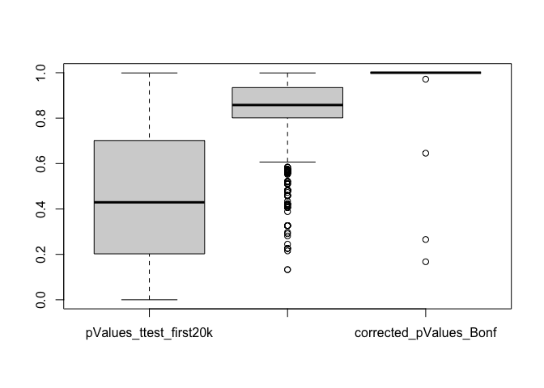

```r
boxplot(final_ttest_first20k_corrected[,9:11])
```

```r
dim(final_ttest_first20k_corrected[final_ttest_first20k_corrected$pValues_ttest<=0.05,])
```

```
## [1] 162  11
```

```r
dim(final_ttest_first20k_corrected[final_ttest_first20k_corrected$corrected_pValues_BH<=0.05,])
```

```
## [1]  0 11
```

```r
dim(final_ttest_first20k_corrected[final_ttest_first20k_corrected$corrected_pValues_Bonf<=0.05,])
```

```
## [1]  0 11
```

**How many probes do you identify as differentially methylated considering nominal pValues?**  
*162 probes remain considering the nomial pValues which are indeed lower before the correction.*

**How many after Bonferroni and BH correction?**  
*There are no significant probes due to the threshold of 0.5 after the correction for both corrections Bonferrini and BH and we must also take into consideration the quantity of samples we are using, which is very small at only 2000.*

### Step 11

**Production of a volcano plot and a Manhattan plot of the results of differential methylation analysis**

```r
beta_first20k <- final_ttest_first20k_corrected[,1:8]

beta_first20k_groupDS <- beta_first20k[,pheno$Group=="DS"]
mean_beta_first20k_groupDS <- apply(beta_first20k_groupDS,1,mean)
beta_first20k_groupWT <- beta_first20k[,pheno$Group=="WT"]
mean_beta_first20k_groupWT <- apply(beta_first20k_groupWT,1,mean)

delta_first20k <- mean_beta_first20k_groupWT-mean_beta_first20k_groupDS
head(delta_first20k)
```

```
##    cg13869341    cg14008030    cg12045430    cg20826792    cg00381604
## -0.0158688749 -0.0059567796  0.0002969574 -0.0131804227  0.0119726093
##    cg20253340
##  0.0479250882
```

```r
toVolcPlot <- data.frame(delta_first20k, -log10(final_ttest_first20k_corrected$pValues_ttest))
head(toVolcPlot)
```

```
##            delta_first20k X.log10.final_ttest_first20k_corrected.pValues_ttest.
## cg13869341  -0.0158688749                                            0.24737342
## cg14008030  -0.0059567796                                            0.33079462
## cg12045430   0.0002969574                                            0.01051754
## cg20826792  -0.0131804227                                            0.26200610
## cg00381604   0.0119726093                                            0.64226295
## cg20253340   0.0479250882                                            0.50849133
```

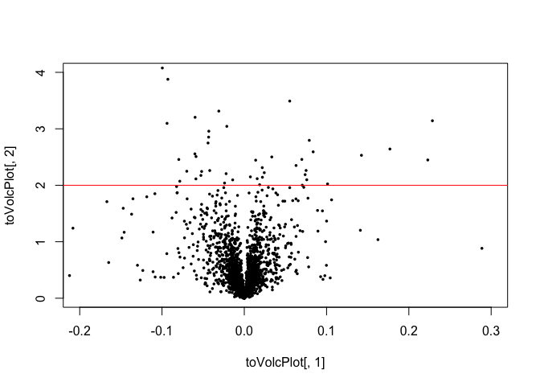

```r
plot(toVolcPlot[,1], toVolcPlot[,2],pch=16,cex=0.5, xlim= c(-0.2,0.3), ylim = c(0,4))
abline(a=-log10(0.01),b=0,col="red")
```

*In the plot is it clear that the data is distributed fairly and has reached the threshold line in red. The difference between the two groups against the pValue is made and those probes that are on the upper area are of interest because they show the largest difference between the two groups with the highest significance due to the lowest pValue.*

**Manhattan plot:**

```r
library(qqman)
final_ttest_first20k_corrected <- data.frame(rownames(final_ttest_first20k_corrected),final_ttest_first20k_corrected)
colnames(final_ttest_first20k_corrected)[1] <- "IlmnID"
final_ttest_first20k_corrected_annotated <- merge(final_ttest_first20k_corrected, Illumina450Manifest_clean,by="IlmnID")

str(final_ttest_first20k_corrected_annotated)
```

```
## 'data.frame':    2000 obs. of  44 variables:
##  $ IlmnID                     : chr  "cg00002593" "cg00007800" "cg00009834" "cg00014118" ...
##  $ X5775278051_R01C02         : num  0.832 0.779 0.797 0.497 0.327 ...
##  $ X5775278078_R01C01         : num  0.847 0.787 0.791 0.499 0.278 ...
##  $ X5775278078_R02C01         : num  0.823 0.74 0.791 0.493 0.205 ...
##  $ X5775278078_R02C02         : num  0.85 0.77 0.807 0.485 0.272 ...
##  $ X5775278078_R04C02         : num  0.842 0.817 0.819 0.55 0.264 ...
##  $ X5930514034_R01C02         : num  0.854 0.796 0.821 0.465 0.285 ...
##  $ X5930514035_R06C02         : num  0.858 0.766 0.814 0.441 0.286 ...
##  $ X5930514054_R06C01         : num  0.841 0.779 0.828 0.525 0.321 ...
##  $ pValues_ttest_first20k     : num  0.9816 0.0385 0.8027 0.5206 0.5585 ...
##  $ corrected_pValues_BH       : num  0.996 0.574 0.967 0.88 0.887 ...
##  $ corrected_pValues_Bonf     : num  1 1 1 1 1 1 1 1 1 1 ...
##  $ Name                       : Factor w/ 485512 levels "cg00000029","cg00000108",..: 60 181 235 339 860 1012 1432 1475 1484 1809 ...
##  $ AddressA_ID                : Factor w/ 485512 levels "10600322","10600328",..: 120318 277560 410861 87708 216277 154324 395531 80362 470185 376807 ...
```

[output cut: 30 more lines]

```r
input_Manhattan <- final_ttest_first20k_corrected_annotated[colnames(final_ttest_first20k_corrected_annotated) %in% c("IlmnID","CHR","MAPINFO","pValues_ttest_first20k")]
dim(input_Manhattan)
```

```
## [1] 2000    4
```

```r
str(input_Manhattan)
```

```
## 'data.frame':    2000 obs. of  4 variables:
##  $ IlmnID                : chr  "cg00002593" "cg00007800" "cg00009834" "cg00014118" ...
##  $ pValues_ttest_first20k: num  0.9816 0.0385 0.8027 0.5206 0.5585 ...
##  $ CHR                   : Factor w/ 24 levels "1","10","11",..: 1 1 1 1 1 1 1 1 1 1 ...
##  $ MAPINFO               : int  1268793 1838518 1347671 1935561 566731 1290712 1355235 1157684 1655803 1564422 ...
```

```r
levels(input_Manhattan$CHR)
```

```
##  [1] "1"  "10" "11" "12" "13" "14" "15" "16" "17" "18" "19" "2"  "20" "21" "22"
## [16] "3"  "4"  "5"  "6"  "7"  "8"  "9"  "X"  "Y"
```

```r
input_Manhattan$CHR <- factor(input_Manhattan$CHR,levels=c("1","2","3","4","5","6","7","8","9","10","11","12","13","14","15","16","17","18","19","20","21","22","X","Y"))
levels(input_Manhattan$CHR)
```

```
##  [1] "1"  "2"  "3"  "4"  "5"  "6"  "7"  "8"  "9"  "10" "11" "12" "13" "14" "15"
## [16] "16" "17" "18" "19" "20" "21" "22" "X"  "Y"
```

```r
input_Manhattan$CHR = as.numeric(input_Manhattan$CHR)
table(input_Manhattan$CHR)
```

```
##
##    1
## 2000
```

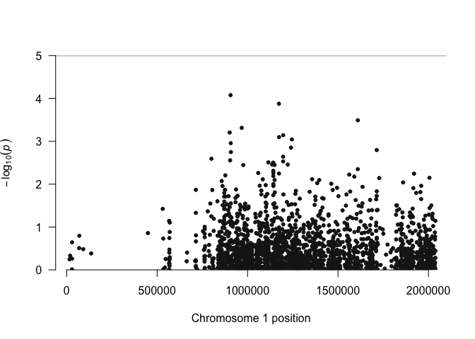

```r
manhattan(input_Manhattan, snp="IlmnID",chr="CHR", bp="MAPINFO", p="pValues_ttest_first20k")
```

*It is important to note that along this chromosome 1, there are less genes and therefore less probes the closer we are to the telomer and this is visible with the plot as you can see the relative number of methylated sites is highly sparse towards the left side.*

### Step 12

```r
library(gplots)
input_heatmap=as.matrix(final_ttest_first20k[1:100,1:8])
pheno$Group
```

```
## [1] DS DS WT WT DS DS WT WT
## Levels: DS WT
```

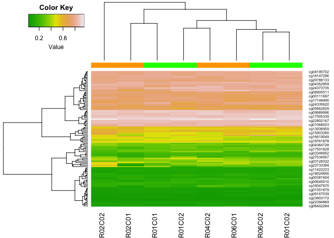

```r
colorbar <- c("green","green","orange","orange","orange","green","green","orange")
heatmap.2(input_heatmap,col=terrain.colors(100),Rowv=T,Colv=T,dendrogram="both",key=T,ColSideColors=colorbar,density.info="none",trace="none",scale="none",symm=F)
```

*Single*

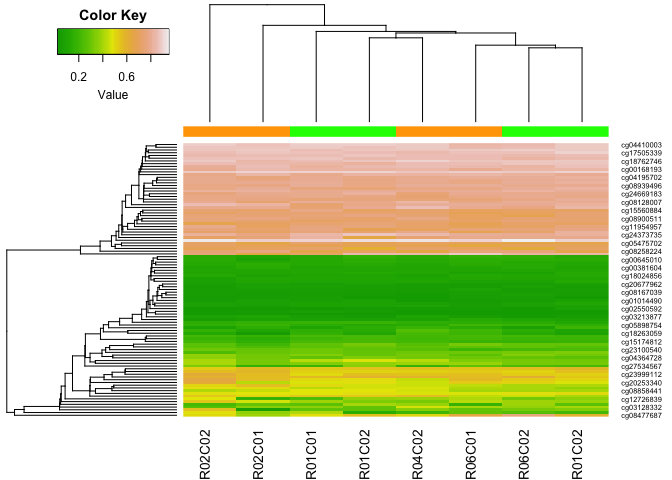

```r
heatmap.2(input_heatmap,col=terrain.colors(100),Rowv=T,Colv=T,hclustfun = function(x) hclust(x,method = 'single'),dendrogram="both",key=T,ColSideColors=colorbar,density.info="none",trace="none",scale="none",symm=F)
```

*Average:*

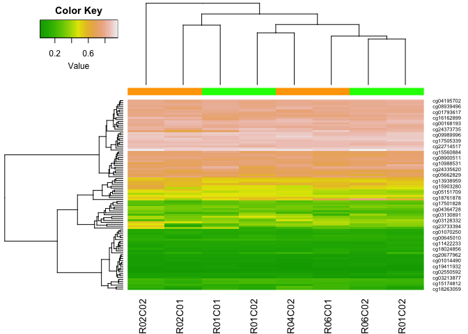

```r
heatmap.2(input_heatmap,col=terrain.colors(100),Rowv=T,Colv=T,hclustfun = function(x) hclust(x,method = 'average'),dendrogram="both",key=T,ColSideColors=colorbar,density.info="none",trace="none",scale="none",symm=F)
```

### *Optional:*

**As DS is caused by the trisomy of chromosome 21, we can plot the density of the methylation values of the probes mapping only on chromosome 21.**

*First the manifest is accessed and specifically chromosome 21 is pulled and assigned, then drop levels is applied to remove unused levels*

```r
chr21 <- Illumina450Manifest_clean[Illumina450Manifest_clean$CHR=="21",]
chr21 <- droplevels(chr21)
dim(chr21)
```

```
## [1] 4243   33
```

```r
str(chr21)
```

```
## 'data.frame':    4243 obs. of  33 variables:
##  $ IlmnID                     : Factor w/ 4243 levels "cg00002080","cg00004533",..: 1 2 3 4 5 6 7 8 9 10 ...
##  $ Name                       : Factor w/ 4243 levels "cg00002080","cg00004533",..: 1 2 3 4 5 6 7 8 9 10 ...
##  $ AddressA_ID                : Factor w/ 4243 levels "10602498","10603403",..: 3081 1447 1478 2309 2872 419 2446 998 2443 1403 ...
##  $ AlleleA_ProbeSeq           : Factor w/ 4243 levels "AAAAAAAAAAATCTAACCTCCTTAATCCTTTTACRTAAACTCTTCAAAAC",..: 3492 1066 3092 405 1495 676 2905 3125 2593 3638 ...
##  $ AddressB_ID                : Factor w/ 1169 levels "","10603336",..: 1 1 1 1 1 1 343 617 1 1 ...
##  $ AlleleB_ProbeSeq           : Factor w/ 1169 levels "","AAAAAAAAAACCTATAAATCACCGTACACGAAAACCCCATAACTAAACCG",..: 1 1 1 1 1 1 834 880 1 1 ...
##  $ Infinium_Design_Type       : Factor w/ 2 levels "I","II": 2 2 2 2 2 2 1 1 2 2 ...
##  $ Next_Base                  : Factor w/ 4 levels "","A","C","T": 1 1 1 1 1 1 2 2 1 1 ...
##  $ Color_Channel              : Factor w/ 3 levels "","Grn","Red": 1 1 1 1 1 1 3 3 1 1 ...
##  $ Forward_Sequence           : Factor w/ 4243 levels "AAAAAAAAAAAAAAAAAAAGGCACTAAAGCCTGGCCCCCATGATGACACAGGAAACTAAT[CG]TCATGGAGACTTTATCCACACTTTTGAATATATGTTACATTTCAACATTAAAACACACAC",..: 1334 2089 2882 3097 722 2515 2624 3717 2568 860 ...
##  $ Genome_Build               : int  37 37 37 37 37 37 37 37 37 37 ...
##  $ CHR                        : Factor w/ 1 level "21": 1 1 1 1 1 1 1 1 1 1 ...
##  $ MAPINFO                    : int  30390417 45402464 48017232 45209230 48026043 34100439 45527029 37432620 34542436 43373079 ...
##  $ SourceSeq                  : Factor w/ 4242 levels "AAAAAAAGATCACAGCCCTCCGATGAGCCGGGCACTATGCGAAGTCTCCG",..: 3091 3608 1936 41 780 2178 2974 3020 764 224 ...
```

[output cut: 19 more lines]

*This is taking the probes from previous normalization procedure.*

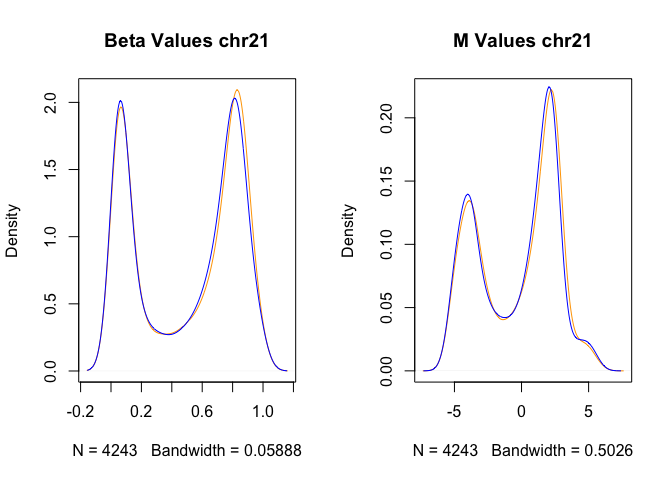

```r
betaWT_21 <- wtBeta[rownames(wtBeta) %in% chr21$IlmnID,]
betaDS_21 <- dsBeta[rownames(dsBeta) %in% chr21$IlmnID,]
mWT_21 <- wtM[rownames(wtM) %in% chr21$IlmnID,]
mDS_21 <- dsM[rownames(dsM) %in% chr21$IlmnID,]

mean_betaWT_21 <- apply(betaWT_21,1,mean)
mean_betaDS_21 <- apply(betaDS_21,1,mean)
mean_mWT_21 <- apply(mWT_21,1,mean)
mean_mDS_21 <- apply(mDS_21,1,mean)

d_mean_betaWT_21 <- density(mean_betaWT_21)
d_mean_betaDS_21 <- density(mean_betaDS_21)
d_mean_mWT_21 <- density(mean_mWT_21)
d_mean_mDS_21 <- density(mean_mDS_21)

par(mfrow = c(1,2))
plot(d_mean_betaWT_21,col="orange", main="Beta Values chr21")
lines(d_mean_betaDS_21, col = "blue")
plot(d_mean_mWT_21, col="orange", main="M Values chr21")
lines(d_mean_mDS_21, col="blue")
```